# Homework 5

## Problem #1: Testing coin flips (6 pts)

In the six sequences below, only one of them is actually **randomly generated from independent flips of a fair coin**. Use a combination of everything you know (common sense, Monte Carlo, hypothesis testing, etc.) to identify which is actually random and explain your reasoning.

(For full points, conduct a formal test and report a p-value for each sequence. You may use a combination of multiple tests to arrive at your answer. If you cannot compute a p-value for each sequence, you can still earn a significant amount of partial credit by carefully explaining your reasoning and response as best as you can.)

My advice is **be creative** with the test statistics you come up with to eliminate each sequence! Think of some way of summarizing a sequence of flips that might be useful for comparing against a simulated sequence of random flips. After you come up with an idea for a statistic, remember to run it on many MC generated completely random flips to produce a distribution under the null, which you can then compare with your data to get a p-value. Also, be careful of now you define “more extreme” than the data.

(2 bonus points available if you can find a single test that is powerful enough to reject all the fake sequences together in one step. Yes, at least one such possible test exists.)

```r
flips1 = "HTHTHTHTHTHTHTHTHTHTHTHTHTHTHTHTHTHTHTHTHTHTHTHTHTHTHTHTHTHT…"

flips2 = "HHHTHTTTHHTHHTHHHTTTTHTHTHHTTHTHHHTHHTHTTTHTHHHTHTTTHTHTHHTH…"

flips3 = "HHTHTHTTTHTHHHTHHTTTHTHHTHTTTHTHTHHTHTHTTHTHHHHHHTTTHTHTHHTH…"

flips4 = "HTHHHHHHHTHTTHHTTHHHTHTHTTTHHTHHHTHHTTHTTTTTTTTTHTHHTTTTTHTH…"

flips5 = "HHHHHHHHHHTTTTTTTTTTHHHHHHHHHHTTTTTTTTTTHHHHHHHHHHTTTTTTTTTT…"

flips6 = "TTHTTTHTTTTTTTHTHTHTHTTHTTHTHHTHHTTTHHTHTTTHTHHTHHHTHTTHHTHH…"

# you can use the function below to split the above sequences in vectors of flips
split = function(str) strsplit(str, split="")[[1]]
split(flips1)
```

```
##   [1] "H" "T" "H" "T" "H" "T" "H" "T" "H" "T" "H" "T" "H" "T" "H" "T" "H" "T"
##  [19] "H" "T" "H" "T" "H" "T" "H" "T" "H" "T" "H" "T" "H" "T" "H" "T" "H" "T"
##  [37] "H" "T" "H" "T" "H" "T" "H" "T" "H" "T" "H" "T" "H" "T" "H" "T" "H" "T"
##  [55] "H" "T" "H" "T" "H" "T" "H" "T" "H" "T" "H" "T" "H" "T" "H" "T" "H" "T"
##  [73] "H" "T" "H" "T" "H" "T" "H" "T" "H" "T" "H" "T" "H" "T" "H" "T" "H" "T"
##  [91] "H" "T" "H" "T" "H" "T" "H" "T" "H" "T" "H" "T" "H" "T" "H" "T" "H" "T"
## [109] "H" "T" "H" "T" "H" "T" "H" "T" "H" "T" "H" "T" "H" "T" "H" "T" "H" "T"
## [127] "H" "T" "H" "T" "H" "T" "H" "T" "H" "T" "H" "T" "H" "T" "H" "T" "H" "T"
## [145] "H" "T" "H" "T" "H" "T" "H" "T" "H" "T" "H" "T" "H" "T" "H" "T" "H" "T"
## [163] "H" "T" "H" "T" "H" "T" "H" "T" "H" "T" "H" "T" "H" "T" "H" "T" "H" "T"
## [181] "H" "T" "H" "T" "H" "T" "H" "T" "H" "T" "H" "T" "H" "T" "H" "T" "H" "T"
## [199] "H" "T"
```

> SOLUTION

> Different ways of testing these flips exist. Students will probably use a combination of methods like number of heads, lengths of runs, etc, which is all fine.

> The one-step test that is powerful enough to reject all but the true sequence is a running tabulation of pairs of successive observations, which for fair and random sequences should be evenly distributed in the sample.

> ```r
> tableOfPairs = function(x) {n=length(x);Rfast::Table(paste(x[1:(n-1)],x[2:n]))}
> varOfTable = function(x) sum((c(x,rep(0,4))[1:4]/sum(x)-0.25)^2)
>
> mc.table.vars = replicate(1e5,varOfTable(tableOfPairs(rbinom(200,1,0.5))))
>
> p1 = mean(mc.table.vars >= (v1 <- varOfTable(tableOfPairs(split(flips1)))))
> p2 = mean(mc.table.vars >= (v2 <- varOfTable(tableOfPairs(split(flips2)))))
> p3 = mean(mc.table.vars >= (v3 <- varOfTable(tableOfPairs(split(flips3)))))
> p4 = mean(mc.table.vars >= (v4 <- varOfTable(tableOfPairs(split(flips4)))))
> p5 = mean(mc.table.vars >= (v5 <- varOfTable(tableOfPairs(split(flips5)))))
> p6 = mean(mc.table.vars >= (v6 <- varOfTable(tableOfPairs(split(flips6)))))
>
> round(values <- c(v1,v2,v3,v4,v5,v6),3)
> ```

> ```
> ## [1] 0.250 0.029 0.015 0.001 0.164 0.044
> ```

> ```r
> round(pvalues <- c(p1,p2,p3,p4,p5,p6),3)
> ```

> ```
> ## [1] 0.000 0.001 0.022 0.833 0.000 0.000
> ```

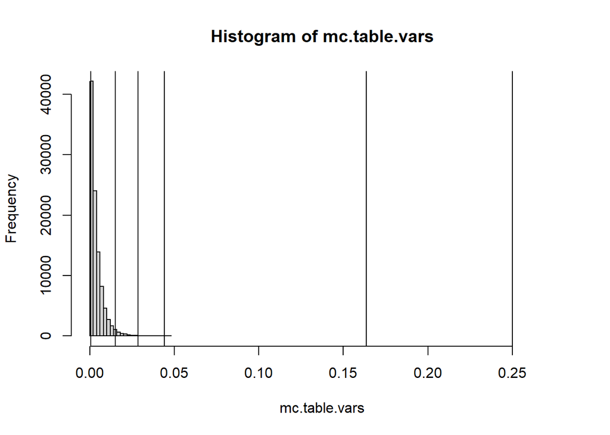

> ```r
> library(tidyverse)
> options(scipen=1e6)
>
> hist(mc.table.vars,xlim=c(0,max(values)*1.1))
> abline(v=values)
> ```

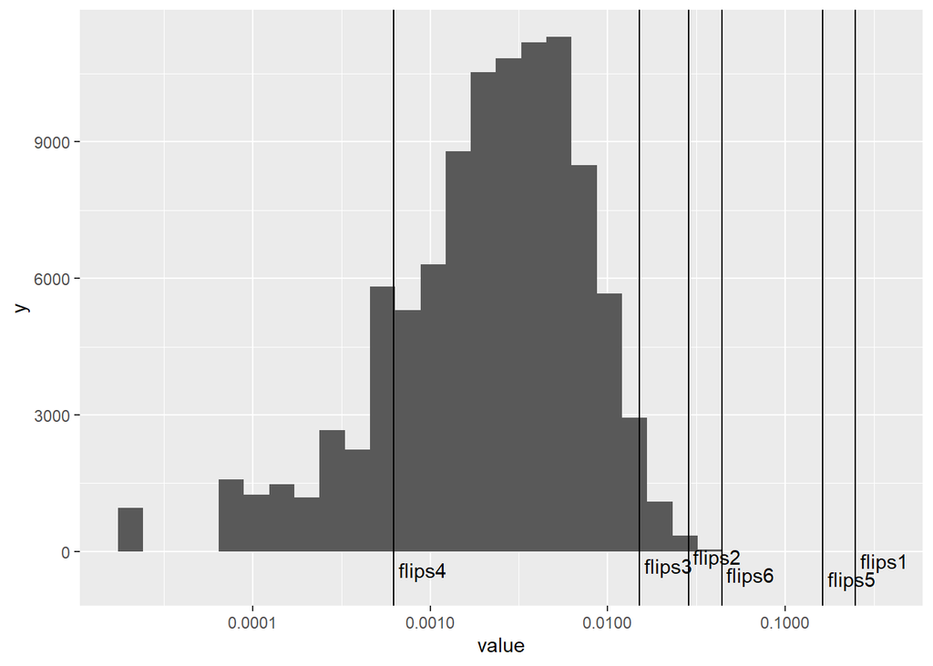

> ```r
> # replot on log scale
> ggplot(data.frame(flips=paste("flips",1:6,sep=""), values=values)) +
>   geom_histogram(data=enframe(mc.table.vars),aes(x=value)) + scale_x_log10() +
>   geom_vline(aes(xintercept=values)) +
>   geom_text(aes(label=flips,x=values,y=0),
>             nudge_y=-100*(1:6)[c(2,1,3,4,6,5)],nudge_x=log10(1.45))
> ```

> This statistic is powerful enough to reject all but flips 4, which is in fact the correct sequence.

## Problem #2: Finding the Trick Coin (6 pts; 2pts each)

I have two coins in my pocket - a trick coin with two heads and a fair coin with one head and one tail(s?). We’ll play a game. I will grab one coin at random, and flip it $N$ times. After that you will have to decide if it is the fair coin or the trick coin. The null hypothesis is that it is the fair coin.

**Decision Rule 1**: If after $N$ flips there are no tails, then you decide it is the trick coin. If there is at least 1 tail then you know it is the fair coin.

1. Using “Decision Rule 1”, what is the lowest number of flips $N$ would you need in order to have a significance level less than 5% for this test?
2. Using $N$ from part a, what is the power of the test?
3. Suppose $N=4$ is decided. How can you modify the decision process to have a significance level of exactly 5%? Does this change the power of the test?
4. Extra Credit (2 points): Suppose if you guess correct you win $100 (and if you’re wrong you get nothing), but each flip of the coin costs $10. What strategy would you use to maximize your expected profit from this game?

> SOLUTION

> ```r
> N <- 1:10
> #pN is the probability of making a type 1 error
> (pN <- .5^N)
> ```

> ```
> ##  [1] 0.5000000000 0.2500000000 0.1250000000 0.0625000000 0.0312500000
> ##  [6] 0.0156250000 0.0078125000 0.0039062500 0.0019531250 0.0009765625
> ```

> The lowest number of flips to give a significance level (Type 1 error rate) < 5% would be 5 flips.

> The power of the test is the probability of rejecting the null under the alt hypothesis. Under the alternative hypothesis (trick coin) you have a 100% probability of rejecting the null, so the power is 100%. In fact no matter which number of flips is used the power will always be 100% because we decide it is the trick coin as long as no tails are flipped - we will never make a false negative decision.

> To modify the decision rule, we can do this: If at least one tail comes up, decide it is the fair coin. If you get 4 heads in a row, then reject the null with probability $p$.
> $$P(Reject|
> H_0)=P(HHHH)P(reject|HHHH)=(.5^4)(p) = .05$$
> If we solve for p we get

> ```r
> .05/.5^4
> ```

> ```
> ## [1] 0.8
> ```

> In this case if the null hypothesis is true we will reject it with probability $(\frac12)^4(.8) = .05$. If the alternative hypothesis is true, then we reject the null hypothesis with probability $.80$, so the power has been reduced to .80.

> ```r
> #Strategy N;p
> for(N in 1:3){
>   for(p in seq(.8,1,.1)){
> #p <- 1
> pN <- .5^(1:N)
> #cost until first tail
> sum((1:N) * 10 * pN)
> #if a tail comes up we know it's fair
> #if we get N heads in a row
> #then we guess it's trick with probability p
> #We are correct if
>    # Fair and we see a tail (1-.5^N)
>     #or
>    # Fair and we guess fair (.5)^N * (1-p)
>     #or
>    # Trick and we guess trick (.5) * p
> EX <- sum((.5)*(.5)^(1:N)*(100-10*1:N))+
>   (.5)*.5^N*(1-p)*(100-10*N)+
>   (.5)*p*(100-10*N)
> print(paste(N, p,EX))
>
> }
> }
> ```

> ```
> ## [1] "1 0.8 63"
> ## [1] "1 0.9 65.25"
> ## [1] "1 1 67.5"
> ## [1] "2 0.8 66.5"
> ## [1] "2 0.9 69.5"
> ## [1] "2 1 72.5"
> ## [1] "3 0.8 65.75"
> ## [1] "3 0.9 68.8125"
> ## [1] "3 1 71.875"
> ```

> ```r
> #N <- 5
> ```

> The most profitable thing to do is to flip it once, if it is a tails then you guess “fair”. Otherwise flip it again. If it is tails guess “fair” otherwise guess “heads”. The expected profit is $72.50

## Problem #3: Testing the maximum of a uniform distribution (8 pts; 2 pts each)

We sample $X_1, X_x,\ldots,X_n \overset{\text{iid}}\sim\text{Uniform}(0,m)$ where $m$ is an unknown maximum. Sleazy Jim tells you that $m=1$ but you’re not so sure. The 50 values sampled are in the following data file:

```r
X <- read.csv("uniform_sample.csv")$x
```

1. Write out in formal notation the null and alternative hypotheses.
2. Come up with a test statistic and measure your sampled data. Is this a one-sided test or two-sided test?
3. Simulate a distribution for the test statistic under the null hypothesis of size at least 1000. Display a histogram of your test statistic distribution.
4. Calculate the $p$-value for this data and make a conclusion.

> SOLUTION

> $H_0: m=1$ $H_1: m<1$

> The test statistic we will use is $T=\max(\text{data})$.

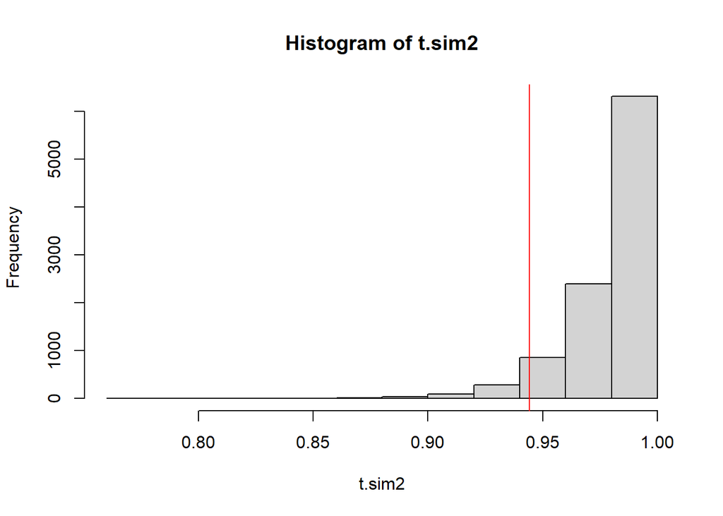

> ```r
> t.sim2 <- 0
> NMC <- 10000
> for(i in 1:NMC){
>   t.sim2[i] <- max(runif(50))
> }
> hist(t.sim2)
> abline(v=max(X), col="red")
> ```

> ```r
> mean(t.sim2 <= max(X))
> ```

> ```
> ## [1] 0.0574
> ```

> The $p$-value is low, but not below 0.05; We would not reject the null hypothesis at $\alpha=0.05$.

> Here are the comparisons of 4 test statistics I came up with. There are many more, I am sure! Is any better than the sample max? You can find that the sample max is the uniformly most powerful test statistic, but that’s beyond the scope of this course.

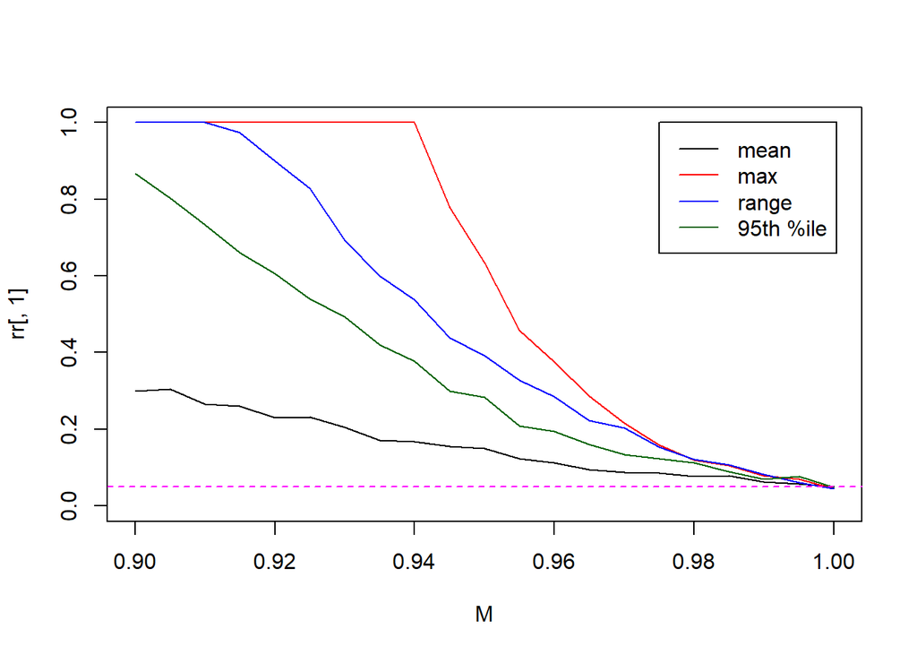

> ```r
> NMC <- 10000
> t.sim <- matrix(nrow=NMC, ncol=4)
> for(i in 1:NMC){
>   t.sim[i,1] <- mean(runif(50))
>   t.sim[i,2] <- max(runif(50))
>   t.sim[i,3] <- diff(range(runif(50)))
>   t.sim[i,4] <- quantile(runif(50), .95)
> }
> M <- seq(.9, 1, .005)
> rr <- matrix(data=0, nrow=length(M), ncol=4)
> for(i in 1:length(M)){
>   m <- M[i]
>   for (j in 1:1000){
>     testData <- runif(50, 0, m)
>     rr[i, 1] <- rr[i,1] + (mean(t.sim[,1] <= mean(testData))<=.05)
>     rr[i, 2] <- rr[i,2] + (mean(t.sim[,2] <= max(testData))<=.05)
>     rr[i, 3] <- rr[i,3] + (mean(t.sim[,3] <= diff(range(testData)))<=.05)
>     rr[i, 4] <- rr[i,4] + (mean(t.sim[,4] <= quantile(testData,.95))<=.05)
>   }
>
> }
> rr <- rr / 1000
> plot(M, y=rr[,1], type="l", ylim=c(0,1))
> lines(M, rr[,2], col="red")
> lines(M, rr[,3], col="blue")
> lines(M, rr[,4], col="darkgreen")
> abline(h=.05, lty=2, col="magenta")
> legend(x=.975, y=1, legend=c("mean","max","range","95th %ile"),
>        col=c("black","red","blue","darkgreen"), lty=1)
> ```

## Problem #4: Rising Temperatures? (10 pts; 2 pt each)

The `annual_avg_temp.csv` data file contains the US annual average temperature from 1875 through 2022.

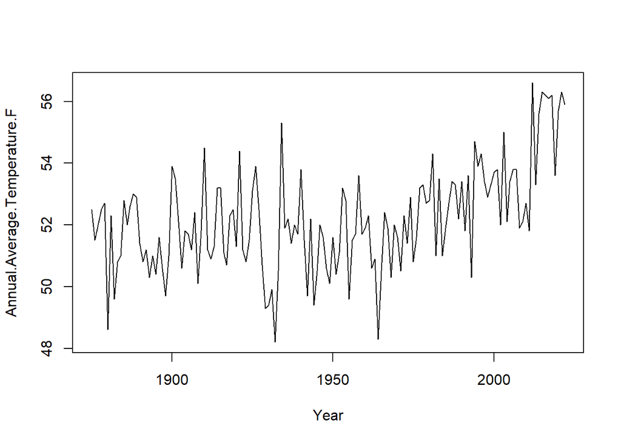

```r
temp <- read.csv("annual_avg_temp.csv")
temps <- temp$Annual.Average.Temperature.F
plot(temp, type="l")
```

There seems to be a trend but it could be due to randomness. Your task is to perform a permutation test on the historical record of annual avg. temperatures to determine if there is statistical evidence of a real trend.

1. State the null and alternative hypotheses
2. Determine a test statistic that identify non-randomness in the temperatures
3. Decide whether the test will be a one or two-tailed test
4. Simulate a distribution of test statistics under the null hypothesis
5. Calculate the test statistic on the observed data, calculate the $p$-value and state your conclusions.

*Hint: basing the test statistic on the differences between consecutive years may be a good idea.*

> SOLUTION

> $H_0:$ There is no trend

> $H_1:$ There is a trend.

> We can look at the differences between consecutive year temperatures. Some statistics that could work:
> - Average absolute difference in consecutive temperatures
> - Average absolute difference in consecutive ranks
> - Standard deviation of temp differences
> - Correlation between temperatures and previous year temp

> We will go with average absolute difference in consecutive ranks. This will lead to a 1-tailed test; if the average difference is noticeably SMALL that means that there is evidence of a trend. A very high average difference would be indicitive of some sort of strange oscillating temperature pattern, but that’s not the kind of trend we’re trying to detect.

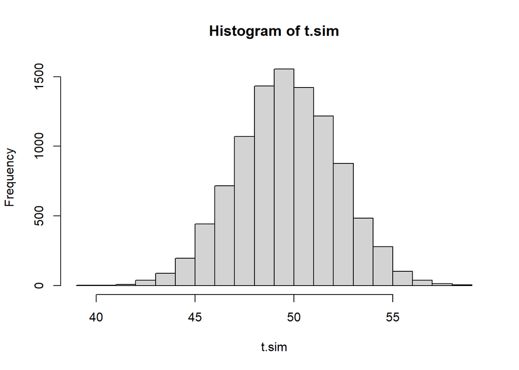

> ```r
> test.stat<-function(temps){
> #  return(mean(abs(diff(temps))))
>   return(mean(abs(diff(rank(temps)))))
> #  return(sd(diff(temps)))
> #  return(cor(temps[-1],temps[-length(temps)]))
> }
>
> set.seed(1)
> temps <- temp$Annual.Average.Temperature.F
> NMC<-10000
> t.sim<-0
> for(i in 1:NMC){
>   shufftemps <- sample(temps)
>   t.sim[i] <- test.stat(shufftemps)
> }
> hist(t.sim)
> ```

> ```r
> test.stat(temps)
> ```

> ```
> ## [1] 36.92857
> ```

> ```r
> mean(t.sim <=test.stat(temps))
> ```

> ```
> ## [1] 0
> ```

> The $p$-value is 0; There’s overwhelming evidence of an actual temperature trend.